# Final Project Summary

Lyn Brush, Huu Phuoc Tran

2026-04-16

Research Topic: Spotify Song Statistics  
Team Members: Lyn (Kalyna) Brush, Huu Phuoc Tran  
Data Description:  
> From website: This is a dataset of Spotify tracks over a range of 125 different genres. Each track has some audio features associated with it. The data is in CSV format which is tabular and can be loaded quickly.  
> There doesn’t seem to be any cleaning that needs to be done, although less specific genre groups could be created as it’s own column (rock, dance, etc). There are some E values that could be difficult to work with.

Link: https://www.kaggle.com/datasets/maharshipandya/-spotify-tracks-dataset?resource=download

```r
# -----------------------------
# 1. Load the dataset
# -----------------------------

spotify_raw <- read_csv("data/dataset.csv", show_col_types = FALSE)
glimpse(spotify_raw)
```

```
## Rows: 114,000
## Columns: 21
## $ ...1             <dbl> 0, 1, 2, 3, 4, 5, 6, 7, 8, 9, 10, 11, 12, 13, 14, 15,…
## $ track_id         <chr> "5SuOikwiRyPMVoIQDJUgSV", "4qPNDBW1i3p13qLCt0Ki3A", "…
## $ artists          <chr> "Gen Hoshino", "Ben Woodward", "Ingrid Michaelson;ZAY…
## $ album_name       <chr> "Comedy", "Ghost (Acoustic)", "To Begin Again", "Craz…
## $ track_name       <chr> "Comedy", "Ghost - Acoustic", "To Begin Again", "Can'…
## $ popularity       <dbl> 73, 55, 57, 71, 82, 58, 74, 80, 74, 56, 74, 69, 52, 6…
## $ duration_ms      <dbl> 230666, 149610, 210826, 201933, 198853, 214240, 22940…
## $ explicit         <lgl> FALSE, FALSE, FALSE, FALSE, FALSE, FALSE, FALSE, FALS…
## $ danceability     <dbl> 0.676, 0.420, 0.438, 0.266, 0.618, 0.688, 0.407, 0.70…
## $ energy           <dbl> 0.4610, 0.1660, 0.3590, 0.0596, 0.4430, 0.4810, 0.147…
## $ key              <dbl> 1, 1, 0, 0, 2, 6, 2, 11, 0, 1, 8, 4, 7, 3, 2, 4, 2, 1…
## $ loudness         <dbl> -6.746, -17.235, -9.734, -18.515, -9.681, -8.807, -8.…
## $ mode             <dbl> 0, 1, 1, 1, 1, 1, 1, 1, 1, 1, 1, 1, 0, 1, 1, 1, 1, 0,…
## $ speechiness      <dbl> 0.1430, 0.0763, 0.0557, 0.0363, 0.0526, 0.1050, 0.035…
## $ acousticness     <dbl> 0.0322, 0.9240, 0.2100, 0.9050, 0.4690, 0.2890, 0.857…
## $ instrumentalness <dbl> 1.01e-06, 5.56e-06, 0.00e+00, 7.07e-05, 0.00e+00, 0.0…
## $ liveness         <dbl> 0.3580, 0.1010, 0.1170, 0.1320, 0.0829, 0.1890, 0.091…
## $ valence          <dbl> 0.7150, 0.2670, 0.1200, 0.1430, 0.1670, 0.6660, 0.076…
## $ tempo            <dbl> 87.917, 77.489, 76.332, 181.740, 119.949, 98.017, 141…
## $ time_signature   <dbl> 4, 4, 4, 3, 4, 4, 3, 4, 4, 4, 4, 3, 4, 4, 4, 3, 4, 4,…
## $ track_genre      <chr> "acoustic", "acoustic", "acoustic", "acoustic", "acou…
```

```r
summary(spotify_raw)
```

```
##       ...1          track_id           artists           album_name
##  Min.   :     0   Length:114000      Length:114000      Length:114000
##  1st Qu.: 28500   Class :character   Class :character   Class :character
##  Median : 57000   Mode  :character   Mode  :character   Mode  :character
##  Mean   : 57000
##  3rd Qu.: 85499
##  Max.   :113999
##   track_name          popularity      duration_ms       explicit
##  Length:114000      Min.   :  0.00   Min.   :      0   Mode :logical
##  Class :character   1st Qu.: 17.00   1st Qu.: 174066   FALSE:104253
##  Mode  :character   Median : 35.00   Median : 212906   TRUE :9747
##                     Mean   : 33.24   Mean   : 228029
##                     3rd Qu.: 50.00   3rd Qu.: 261506
##                     Max.   :100.00   Max.   :5237295
##   danceability        energy            key            loudness
##  Min.   :0.0000   Min.   :0.0000   Min.   : 0.000   Min.   :-49.531
##  1st Qu.:0.4560   1st Qu.:0.4720   1st Qu.: 2.000   1st Qu.:-10.013
##  Median :0.5800   Median :0.6850   Median : 5.000   Median : -7.004
##  Mean   :0.5668   Mean   :0.6414   Mean   : 5.309   Mean   : -8.259
##  3rd Qu.:0.6950   3rd Qu.:0.8540   3rd Qu.: 8.000   3rd Qu.: -5.003
##  Max.   :0.9850   Max.   :1.0000   Max.   :11.000   Max.   :  4.532
##       mode         speechiness       acousticness    instrumentalness
##  Min.   :0.0000   Min.   :0.00000   Min.   :0.0000   Min.   :0.00e+00
##  1st Qu.:0.0000   1st Qu.:0.03590   1st Qu.:0.0169   1st Qu.:0.00e+00
##  Median :1.0000   Median :0.04890   Median :0.1690   Median :4.16e-05
##  Mean   :0.6376   Mean   :0.08465   Mean   :0.3149   Mean   :1.56e-01
##  3rd Qu.:1.0000   3rd Qu.:0.08450   3rd Qu.:0.5980   3rd Qu.:4.90e-02
##  Max.   :1.0000   Max.   :0.96500   Max.   :0.9960   Max.   :1.00e+00
##     liveness         valence           tempo        time_signature
##  Min.   :0.0000   Min.   :0.0000   Min.   :  0.00   Min.   :0.000
##  1st Qu.:0.0980   1st Qu.:0.2600   1st Qu.: 99.22   1st Qu.:4.000
##  Median :0.1320   Median :0.4640   Median :122.02   Median :4.000
##  Mean   :0.2136   Mean   :0.4741   Mean   :122.15   Mean   :3.904
##  3rd Qu.:0.2730   3rd Qu.:0.6830   3rd Qu.:140.07   3rd Qu.:4.000
##  Max.   :1.0000   Max.   :0.9950   Max.   :243.37   Max.   :5.000
##  track_genre
##  Length:114000
##  Class :character
##  Mode  :character
##
##
##
```

```r
# -----------------------------
# 2. Clean the dataset
# -----------------------------

spotify_clean <- spotify_raw %>%
  select(-any_of(c("...1", "X", "X1", "Unnamed: 0"))) %>%
  distinct() %>%
  drop_na(
    track_genre,
    danceability,
    energy,
    tempo,
    acousticness,
    valence,
    speechiness,
    loudness,
    instrumentalness,
    liveness,
    duration_ms
  ) %>%
  mutate(
    duration_min = duration_ms / 60000,
    track_genre = as.factor(track_genre),
    explicit = as.factor(explicit),
    key = as.factor(key),
    mode = as.factor(mode),
    time_signature = as.factor(time_signature)
  )

glimpse(spotify_clean)
```

```
## Rows: 113,550
## Columns: 21
## $ track_id         <chr> "5SuOikwiRyPMVoIQDJUgSV", "4qPNDBW1i3p13qLCt0Ki3A", "…
## $ artists          <chr> "Gen Hoshino", "Ben Woodward", "Ingrid Michaelson;ZAY…
## $ album_name       <chr> "Comedy", "Ghost (Acoustic)", "To Begin Again", "Craz…
## $ track_name       <chr> "Comedy", "Ghost - Acoustic", "To Begin Again", "Can'…
## $ popularity       <dbl> 73, 55, 57, 71, 82, 58, 74, 80, 74, 56, 74, 69, 52, 6…
## $ duration_ms      <dbl> 230666, 149610, 210826, 201933, 198853, 214240, 22940…
## $ explicit         <fct> FALSE, FALSE, FALSE, FALSE, FALSE, FALSE, FALSE, FALS…
## $ danceability     <dbl> 0.676, 0.420, 0.438, 0.266, 0.618, 0.688, 0.407, 0.70…
## $ energy           <dbl> 0.4610, 0.1660, 0.3590, 0.0596, 0.4430, 0.4810, 0.147…
## $ key              <fct> 1, 1, 0, 0, 2, 6, 2, 11, 0, 1, 8, 4, 7, 3, 2, 4, 2, 1…
## $ loudness         <dbl> -6.746, -17.235, -9.734, -18.515, -9.681, -8.807, -8.…
## $ mode             <fct> 0, 1, 1, 1, 1, 1, 1, 1, 1, 1, 1, 1, 0, 1, 1, 1, 1, 0,…
## $ speechiness      <dbl> 0.1430, 0.0763, 0.0557, 0.0363, 0.0526, 0.1050, 0.035…
## $ acousticness     <dbl> 0.0322, 0.9240, 0.2100, 0.9050, 0.4690, 0.2890, 0.857…
## $ instrumentalness <dbl> 1.01e-06, 5.56e-06, 0.00e+00, 7.07e-05, 0.00e+00, 0.0…
## $ liveness         <dbl> 0.3580, 0.1010, 0.1170, 0.1320, 0.0829, 0.1890, 0.091…
## $ valence          <dbl> 0.7150, 0.2670, 0.1200, 0.1430, 0.1670, 0.6660, 0.076…
## $ tempo            <dbl> 87.917, 77.489, 76.332, 181.740, 119.949, 98.017, 141…
## $ time_signature   <fct> 4, 4, 4, 3, 4, 4, 3, 4, 4, 4, 4, 3, 4, 4, 4, 3, 4, 4,…
## $ track_genre      <fct> acoustic, acoustic, acoustic, acoustic, acoustic, aco…
## $ duration_min     <dbl> 3.844433, 2.493500, 3.513767, 3.365550, 3.314217, 3.5…
```

Project idea / research questions:

> I am planning to analyze whether How do mood-related Spotify audio features differ across selected music genres? I chose this question because different genres may create different emotional feelings for listeners. For example, some genres may sound more energetic, danceable, positive, or fast-paced than others. In this project, I focus on mood-related audio features such as valence, energy, danceability, and tempo. Instead of training a prediction model, I use exploratory data analysis and visualizations to compare how these mood features vary across genres.

```r
# -----------------------------
# 3. Choose selected genres
# -----------------------------

genres_to_use <- c(
  "pop", "rock", "hip-hop", "jazz", "classical",
  "country", "metal", "acoustic", "dance", "edm"
)

spotify_focus <- spotify_clean %>%
  filter(track_genre %in% genres_to_use) %>%
  mutate(track_genre = fct_drop(track_genre))

spotify_focus %>%
  count(track_genre, sort = TRUE)
```

```
## # A tibble: 10 × 2
##    track_genre     n
##    <fct>       <int>
##  1 acoustic     1000
##  2 country      1000
##  3 rock         1000
##  4 jazz          999
##  5 metal         998
##  6 edm           993
##  7 pop           993
##  8 hip-hop       991
##  9 dance         965
## 10 classical     933
```

I selected 10 genres from the full Spotify dataset because the original dataset has many genre categories. Using a smaller group makes the analysis easier to visualize and compare. The selected genres have similar sample sizes, with most genres having around 900 to 1,000 songs, so the comparison is fairly balanced.

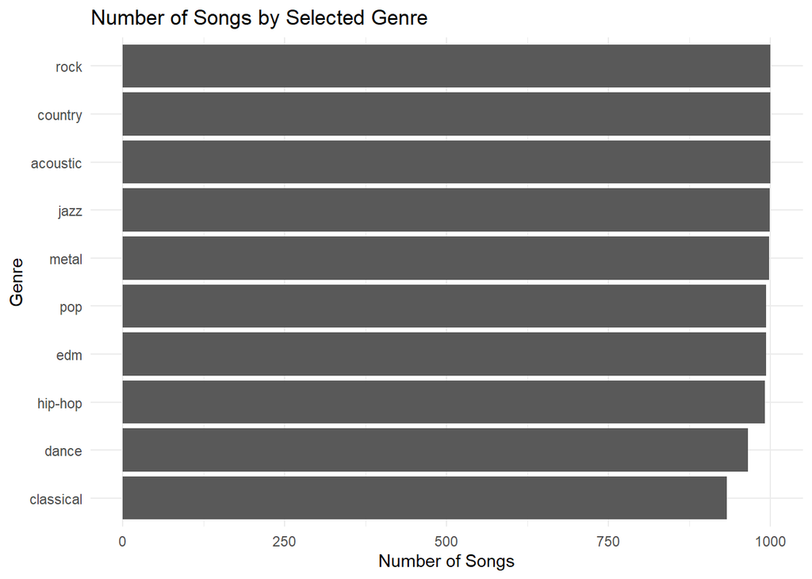

```r
# ============================================================
# 4. Plot number of songs by genre
# ============================================================

spotify_focus %>%
  count(track_genre, sort = TRUE) %>%
  ggplot(aes(x = reorder(track_genre, n), y = n)) +
  geom_col() +
  coord_flip() +
  labs(
    title = "Number of Songs by Selected Genre",
    x = "Genre",
    y = "Number of Songs"
  ) +
  theme_minimal()
```

This bar chart shows the number of songs in each selected genre. Most genres have close to 1,000 songs, while a few genres such as classical and dance have slightly fewer songs. Overall, the selected genres are fairly balanced, which makes the comparison between genres more reliable and easier to interpret.

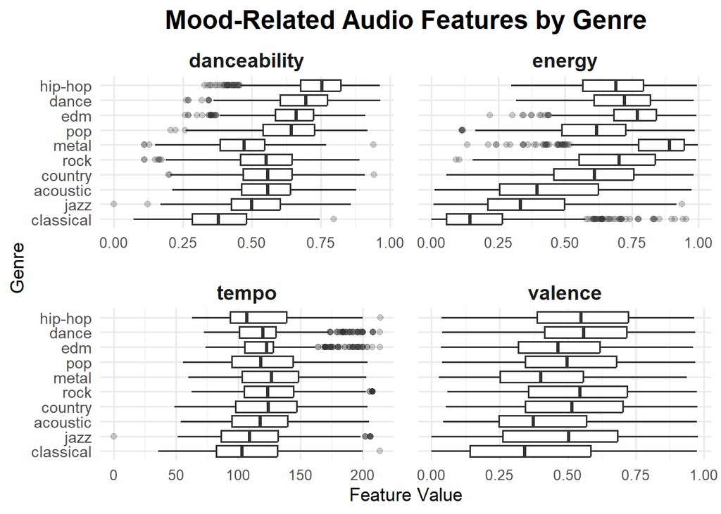

```r
# ============================================================
# 5. Mood feature distributions by genre
# ============================================================

mood_features <- c("danceability", "energy", "valence", "tempo")

spotify_mood_long <- spotify_focus %>%
  select(track_genre, all_of(mood_features)) %>%
  pivot_longer(
    cols = all_of(mood_features),
    names_to = "mood_feature",
    values_to = "value"
  )

ggplot(
  spotify_mood_long,
  aes(
    x = value,
    y = fct_reorder(track_genre, value, .fun = median)
  )
) +
  geom_boxplot(outlier.alpha = 0.25) +
  facet_wrap(
    ~ mood_feature,
    scales = "free_x",
    ncol = 2
  ) +
  labs(
    title = "Mood-Related Audio Features by Genre",
    x = "Feature Value",
    y = "Genre"
  ) +
  theme_minimal(base_size = 13) +
  theme(
    plot.title = element_text(size = 18, face = "bold", hjust = 0.5),
    strip.text = element_text(size = 14, face = "bold"),
    axis.text.y = element_text(size = 11),
    axis.text.x = element_text(size = 10),
    panel.spacing = unit(1.2, "lines")
  )
```

This set of boxplots compares four mood-related audio features across selected genres: danceability, energy, tempo, and valence. Danceability shows how suitable a song is for dancing, energy shows how intense the song feels, tempo shows the song speed in BPM, and valence shows how positive or cheerful the song sounds. The chart helps show that different genres have different mood patterns, although many genres still overlap.

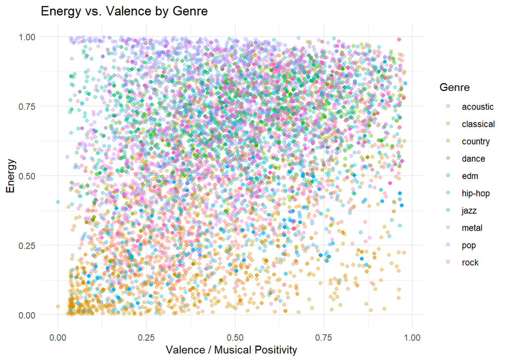

```r
# ============================================================
# 6. Energy vs Valence
# ============================================================

ggplot(
  spotify_focus,
  aes(x = valence, y = energy, color = track_genre)
) +
  geom_point(alpha = 0.35) +
  labs(
    title = "Energy vs. Valence by Genre",
    x = "Valence / Musical Positivity",
    y = "Energy",
    color = "Genre"
  ) +
  theme_minimal()
```

This scatterplot compares energy and valence for songs in different genres. Songs near the top of the chart have higher energy, while songs farther to the right have higher musical positivity. The plot shows that many songs overlap across genres, meaning that energy and valence alone cannot perfectly separate genres. However, it still helps identify general mood patterns, such as which genres tend to be more energetic or more positive.

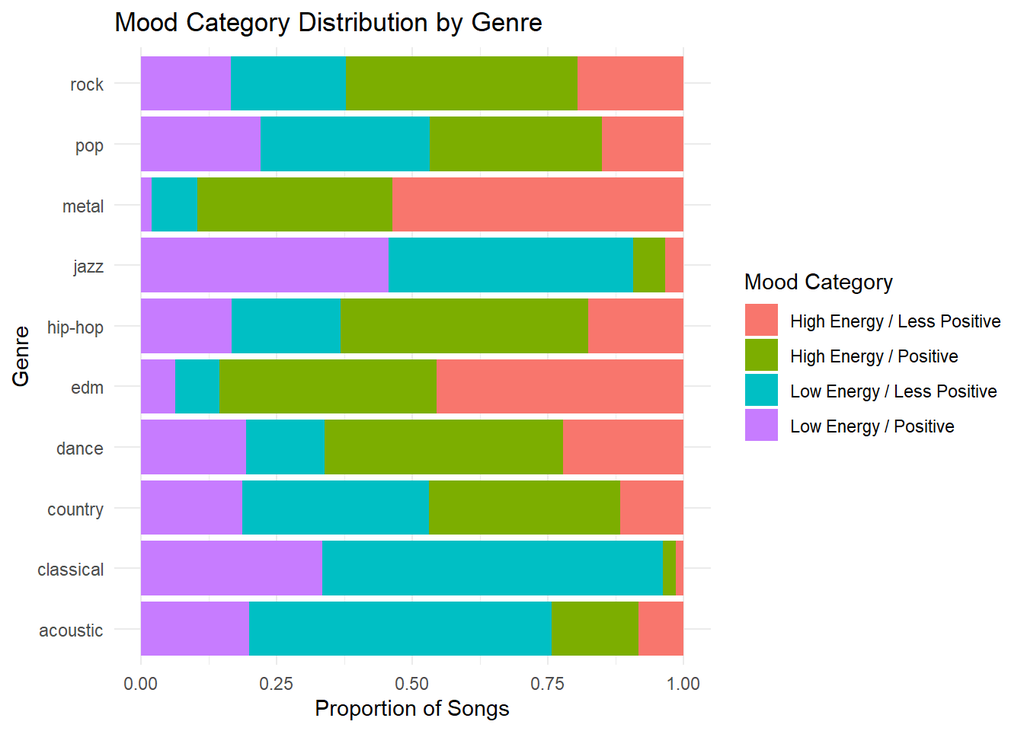

```r
# ============================================================
# 7. Simple mood categories
# ============================================================

spotify_mood_category <- spotify_focus %>%
  mutate(
    mood_category = case_when(
      energy >= median(energy, na.rm = TRUE) & valence >= median(valence, na.rm = TRUE) ~ "High Energy / Positive",
      energy >= median(energy, na.rm = TRUE) & valence < median(valence, na.rm = TRUE) ~ "High Energy / Less Positive",
      energy < median(energy, na.rm = TRUE) & valence >= median(valence, na.rm = TRUE) ~ "Low Energy / Positive",
      TRUE ~ "Low Energy / Less Positive"
    )
  )

spotify_mood_category %>%
  count(track_genre, mood_category) %>%
  ggplot(aes(x = track_genre, y = n, fill = mood_category)) +
  geom_col(position = "fill") +
  coord_flip() +
  labs(
    title = "Mood Category Distribution by Genre",
    x = "Genre",
    y = "Proportion of Songs",
    fill = "Mood Category"
  ) +
  theme_minimal()
```

This stacked bar chart groups songs into four simple mood categories based on energy and valence: High Energy / Positive, High Energy / Less Positive, Low Energy / Positive, and Low Energy / Less Positive. Each bar shows the proportion of songs in each mood category for a genre. This chart makes it easier to compare the overall mood profile of each genre. For example, some genres have a larger share of high-energy songs, while others have more low-energy or less-positive songs.

> I’m planning to investigate the averages for columns like “acousticness” and “speechiness” by genre, as well as popular keys, bpms, and the most common duration. I also want to see how these things affect the popularity score.  
> I will likely use a lot of histograms and box plots to see averages, and scatterplots to see trendlines.